# Text Classification in Python

## Feature Importance:

### MDI importances:

`feature_importances_` gives a numerical importance score assigned to each feature by the Random Forest classifier and is calculated using the Mean Decrease in Impurity (MDI) method. This method computes the importance score of a feature based on the decrease in impurity (typically measured using the Gini impurity) achieved by splitting the data based on that feature during the construction of individual decision trees in the Random Forest ensemble.

**But** feature importances simply tells us which one of the features were more useful when building the model. They should not to be interpreted as coefficients (we can not interpret them as "correlations" or "strength coefficients") giving a direct dependence between predictor and target. If your model does not generalize to validation data, then feature importances have no meaning [1](https://stats.stackexchange.com/questions/450703/is-feature-importance-in-random-forest-useless).

Feature importances are specific to the training data used to build the model. If the model does not generalize well to unseen data, such as validation or test data, then the feature importances may not accurately reflect the true importance of features in making predictions on new data.

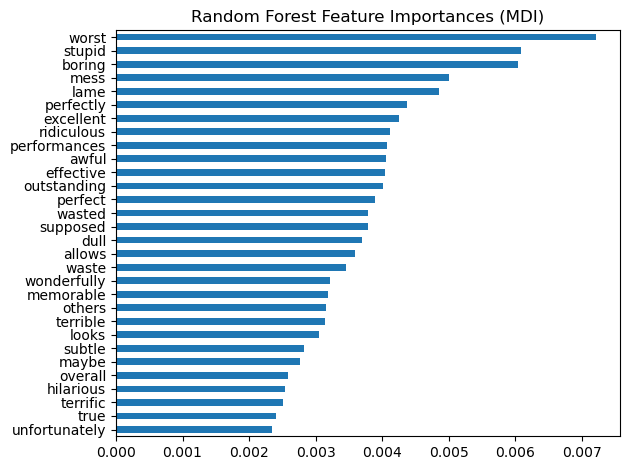

```python
mdi_importances = pd.Series(
    classifier_rf.feature_importances_, index=rf_vocab_list
)

ax = mdi_importances.sort_values(ascending=True)[-30:].plot.barh()
ax.set_title("Random Forest Feature Importances (MDI)")
ax.figure.tight_layout()
```

```python
top_word_indices = np.argsort(mdi_importances)[::-1][:30]
print(rf_vocab_list[top_word_indices.values])
print(mdi_importances.values[top_word_indices.values])
```

```
['worst' 'stupid' 'boring' 'mess' 'lame' 'perfectly' 'excellent'
 'ridiculous' 'performances' 'awful' 'effective' 'outstanding' 'perfect'
 'wasted' 'supposed' 'dull' 'allows' 'waste' 'wonderfully' 'memorable'
 'others' 'terrible' 'looks' 'subtle' 'maybe' 'overall' 'hilarious'
 'terrific' 'true' 'unfortunately']
[0.00721143 0.00609041 0.00603721 0.00499713 0.00485021 0.00437587
 0.00424904 0.00411215 0.00406847 0.00405618 0.00403702 0.00401124
 0.00388677 0.00378624 0.00378257 0.00369268 0.00359577 0.00345391
 0.00321271 0.00318997 0.0031568  0.00313495 0.00304673 0.00281922
 0.002758   0.00258836 0.00254304 0.00251487 0.00240151 0.00234664]
```

### Permutation importances [(docs)](https://scikit-learn.org/stable/auto_examples/inspection/plot_permutation_importance.html)

Another approach is to calculate the permutation importances of rf that are computed on a held out test set. They measure the decrease in model performance (for eample, in terms of accuracy/F1 etc., in classification tasks) when the values of a feature are randomly permuted. By comparing the model's performance with the original feature values to its performance with permuted feature values, we can determine the importance of each feature in making accurate predictions.

The permutation importances are computed on a metric of your choice(accuracy/precision/recall etc.), they are easier to interpret and can in some sense be seen as a "strength coefficient", since they answer the question: "How much does the performance of my model degrade if I shuffle this predictor?"[1](https://stats.stackexchange.com/questions/450703/is-feature-importance-in-random-forest-useless)

```python
from sklearn.inspection import permutation_importance

# Measures the decrease in model performance when the values of each feature are randomly shuffled.
# The analysis is repeated 10 to obtain estimates of feature importance.
# The results include the mean importance, standard deviation, and confidence interval for each feature.
permute_importances = permutation_importance(
    classifier_rf, rf_X_test.toarray(), y_test, n_repeats=100, random_state=42, n_jobs=5, scoring="accuracy"
)
```

```python
#sorted_idx =
# Create a DataFrame from permutation importances
permute_importances_df = pd.DataFrame({
    'importances_mean': permute_importances.importances_mean,
    'importances_std': permute_importances.importances_std},
index = rf_vocab_list)
#permute_importances_df["word"] = rf_vocab_list
permute_importances_df = permute_importances_df.sort_values("importances_mean", ascending=False)
permute_importances_df.head()
```

|  | importances_mean | importances_std |
| --- | --- | --- |
| worst | 0.019750 | 0.006629 |
| boring | 0.018600 | 0.006096 |
| mess | 0.012975 | 0.005902 |
| awful | 0.012350 | 0.005301 |
| dull | 0.008875 | 0.004588 |

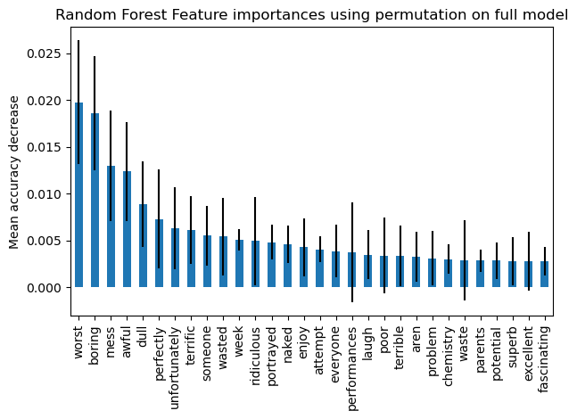

```python
import matplotlib.pyplot as plt
top_n = 30
fig, ax = plt.subplots()
permute_importances_df.importances_mean[:top_n].plot.bar(yerr=permute_importances_df.importances_std[:top_n], ax=ax)
ax.set_title("Random Forest Feature importances using permutation on full model")
ax.set_ylabel("Mean accuracy decrease")
fig.tight_layout()
plt.show()
```

# ROC

The Receiver Operating Characteristic (ROC) curve is a graphical representation of the performance of a binary classification model across different threshold settings. It plots the true positive rate (Sensitivity) against the false positive rate (1 - Specificity) for various threshold values. Each point on the curve represents the performance of the model at a particular threshold setting. A diagonal line from the bottom left corner to the top right corner represents the performance of a random classifier. The ROC curve looks in more depth at the underlying scores / probability statements that indicate how sure the classifier is.

A perfect classifier would have a ROC curve that passes through the top left corner (true positive rate of 1 and false positive rate of 0), indicating that it achieves perfect sensitivity (correctly identifies all positive samples) while making no false positive predictions.

The area under the ROC curve (AUC) is a summary measure of the classifier's performance, with higher values indicating better discrimination between the positive and negative classes. It provides a single value summarizing the overall performance of the classifier.

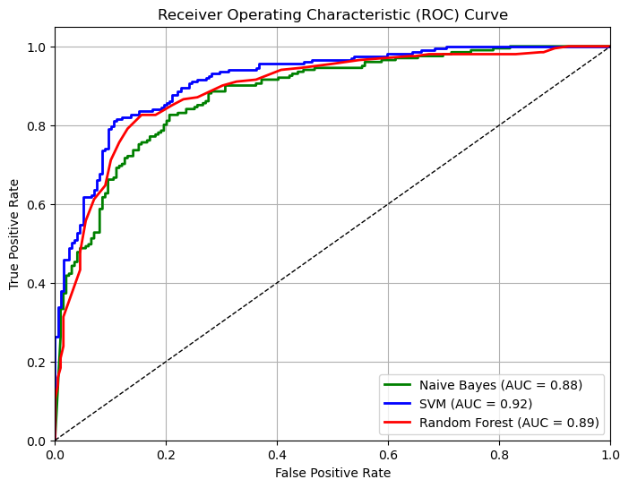

```python
from sklearn.metrics import roc_curve, auc

# Assuming 'predicted_proba_svm', 'predicted_proba_rf', 'predicted_proba_naive', 'actual_class' are numpy arrays or pandas Series

# Calculate ROC curve and AUC for Naive Bayes
fpr_naive, tpr_naive, _ = roc_curve(y_test, predicted_prob_nb[:, 1])
roc_auc_naive = auc(fpr_naive, tpr_naive)

actual_class = y_test
# Calculate ROC curve and AUC for SVM
fpr_svm, tpr_svm, _ = roc_curve(y_test, predicted_proba_svm[:, 1])
roc_auc_svm = auc(fpr_svm, tpr_svm)

# Calculate ROC curve and AUC for Random Forest
fpr_rf, tpr_rf, _ = roc_curve(y_test, predicted_proba_rf[:, 1])
roc_auc_rf = auc(fpr_rf, tpr_rf)

# Plot ROC curves
plt.figure(figsize=(8, 6))
plt.plot(fpr_naive, tpr_naive, color='green', lw=2, label=f'Naive Bayes (AUC = {roc_auc_naive:.2f})')
plt.plot(fpr_svm, tpr_svm, color='blue', lw=2, label=f'SVM (AUC = {roc_auc_svm:.2f})')
plt.plot(fpr_rf, tpr_rf, color='red', lw=2, label=f'Random Forest (AUC = {roc_auc_rf:.2f})')
plt.plot([0, 1], [0, 1], color='black', lw=1, linestyle='--')
plt.xlim([0.0, 1.0])
plt.ylim([0.0, 1.05])
plt.xlabel('False Positive Rate')
plt.ylabel('True Positive Rate')
plt.title('Receiver Operating Characteristic (ROC) Curve')
plt.legend(loc='lower right')
plt.grid(True)
plt.show()
```

SVM is slightly better, followed by the Random Forest abd Naive Bayes. We used much less information in building the Random Forest because of computation time but its performace is suprisingly comparable to the others.